# Statistics for Data Science with `R`

# Ordered Logit Examples

```r
require(lattice)
require(nnet)
require(vcd)
require(faraway)
require(ggplot2)
require(MASS)
require(qdata)
```

## Example: National Election Study

### Data description

For this example we sill use the same data one above examples, but we will consider the `sPID` dependent variable as ordered, with `Democrat` < `Independent` < `Republican` (an ordering “from left to right” in political affiliation).  
A function that we may use to fit ordered logit models is `polr()`, which is part of the recommended `MASS` package.

### Data loading

```r
data(nes96)

# We create a new variabile that will contain recoded `PID` data  [*]
sPID <- nes96$PID
levels(sPID) <-  c("Democrat","Democrat","Independent","Independent",
                  "Independent","Republican","Republican")
summary(sPID)
```

```
##    Democrat Independent  Republican
##         380         239         325
```

```r
nes96$sPID=sPID
```

### Inference and models

```r
# Now we create a new numerical `nincome` variable containing the numerical transformation of original ordered-factor `income` variable, using midpoints of each range: [*]
inca <- c(1.5,4,6,8,9.5,10.5,11.5,12.5,13.5,14.5,16,18.5,21,23.5,
         27.5,32.5,37.5,42.5,47.5,55,67.5,82.5,97.5,115)
nincome <- inca[unclass(nes96$income)]
nes96$nincome=nincome
summary(nes96$nincome)
```

```
##    Min. 1st Qu.  Median    Mean 3rd Qu.    Max.
##    1.50   23.50   37.50   46.58   67.50  115.00
```

```r
(pomod0 <- polr(sPID ~ age + educ + nincome, data=nes96))
```

```
## Call:
## polr(formula = sPID ~ age + educ + nincome, data = nes96)
##
## Coefficients:
##          age       educ.L       educ.Q       educ.C       educ^4
##  0.005774902  0.724086814 -0.781360508  0.040168238 -0.019925492
##       educ^5       educ^6      nincome
## -0.079412657 -0.061103738  0.012738693
##
## Intercepts:
##   Democrat|Independent Independent|Republican
##              0.6448794              1.7373541
##
## Residual Deviance: 1984.211
## AIC: 2004.211
```

```r
summary(pomod0)
```

```
##
## Re-fitting to get Hessian
```

```
## Call:
## polr(formula = sPID ~ age + educ + nincome, data = nes96)
##
## Coefficients:
##             Value Std. Error  t value
## age      0.005775   0.003887  1.48581
## educ.L   0.724087   0.384388  1.88374
## educ.Q  -0.781361   0.351173 -2.22500
## educ.C   0.040168   0.291762  0.13767
## educ^4  -0.019925   0.232429 -0.08573
## educ^5  -0.079413   0.191533 -0.41462
## educ^6  -0.061104   0.157747 -0.38735
## nincome  0.012739   0.002140  5.95187
##
## Intercepts:
##                        Value   Std. Error t value
## Democrat|Independent    0.6449  0.2435     2.6479
## Independent|Republican  1.7374  0.2493     6.9694
##
## Residual Deviance: 1984.211
## AIC: 2004.211
```

```r
(mmod0 <- multinom(sPID ~ age + educ + nincome, data=nes96))
```

```
## Call:
## multinom(formula = sPID ~ age + educ + nincome, data = nes96)
##
## Coefficients:
##             (Intercept)          age     educ.L     educ.Q    educ.C
## Independent   -1.197260 0.0001534525 0.06351451 -0.1217038 0.1119542
## Republican    -1.642656 0.0081943691 1.19413345 -1.2292869 0.1544575
##                  educ^4     educ^5      educ^6    nincome
## Independent -0.07657336  0.1360851  0.15427826 0.01623911
## Republican  -0.02827297 -0.1221176 -0.03741389 0.01724679
##
## Residual Deviance: 1968.333
## AIC: 2004.333
```

```r
mmod <- step(mmod0)
```

```
## Start:  AIC=2004.33
## sPID ~ age + educ + nincome
##
## trying - age
## trying - educ
## trying - nincome
##           Df      AIC
## - educ     6 1996.539
## - age     16 2003.625
## <none>    18 2004.333
## - nincome 16 2045.911
##
## Step:  AIC=1996.54
## sPID ~ age + nincome
##
## trying - age
## trying - nincome
##           Df      AIC
## - age      4 1993.424
## <none>     6 1996.539
## - nincome  4 2048.850
##
## Step:  AIC=1993.42
## sPID ~ nincome
##
## trying - nincome
##           Df      AIC
## <none>     4 1993.424
## - nincome  2 2045.272
```

```r
il <- c(8,26,42,58,74,90,107)
```

Also, as stated in theoretical paragraphs, there are several other link functions, related to the underliyng latent variable: “probit”, “cloglog”, and “cauchit”. The parameter that assesses the type of distribution with `polr()` is `method`.

Anyway, if we want to find automatically a “good” model that fits the data, we can use the `step()` function, as in previous examples:

```r
pomod <- step(pomod0)
```

```
## Start:  AIC=2004.21
## sPID ~ age + educ + nincome
##
##           Df    AIC
## - educ     6 2002.8
## <none>       2004.2
## - age      1 2004.4
## - nincome  1 2038.6
##
## Step:  AIC=2002.83
## sPID ~ age + nincome
##
##           Df    AIC
## - age      1 2001.4
## <none>       2002.8
## - nincome  1 2047.2
##
## Step:  AIC=2001.36
## sPID ~ nincome
##
##           Df    AIC
## <none>       2001.4
## - nincome  1 2045.3
```

```r
summary(pomod)
```

```
##
## Re-fitting to get Hessian
```

```
## Call:
## polr(formula = sPID ~ nincome, data = nes96)
##
## Coefficients:
##           Value Std. Error t value
## nincome 0.01312   0.001971   6.657
##
## Intercepts:
##                        Value   Std. Error t value
## Democrat|Independent    0.2091  0.1123     1.8627
## Independent|Republican  1.2916  0.1201    10.7526
##
## Residual Deviance: 1995.363
## AIC: 2001.363
```

The difference of deviance between complete and reduced model allows the researcher to assess the significancy of removed terms:

```r
(diff <- deviance(pomod)-deviance(pomod0))
```

```
## [1] 11.15136
```

```r
pchisq(diff, pomod0$edf-pomod$edf,lower=F)
```

```
## [1] 0.1321517
```

This is also the same of using `anova()`:

```r
anova(pomod,pomod0,test="Chisq")
```

```
## Likelihood ratio tests of ordinal regression models
##
## Response: sPID
##                  Model Resid. df Resid. Dev   Test    Df LR stat.
## 1              nincome       941   1995.363
## 2 age + educ + nincome       934   1984.211 1 vs 2     7 11.15136
##     Pr(Chi)
## 1
## 2 0.1321517
```

However, to reduce the model it is possible also to use `dropterm()`:

```r
dropterm(pomod0, test="Chisq")
```

```
## Single term deletions
##
## Model:
## sPID ~ age + educ + nincome
##         Df    AIC    LRT   Pr(Chi)
## <none>     2004.2
## age      1 2004.4  2.210    0.1371
## educ     6 2002.8 10.619    0.1009
## nincome  1 2038.6 36.430 1.583e-09 ***
## ---
## Signif. codes:  0 '***' 0.001 '**' 0.01 '*' 0.05 '.' 0.1 ' ' 1
```

```r
pomod1 <- polr(sPID ~ educ + nincome, data=nes96)
dropterm(pomod1, test="Chisq")
```

```
## Single term deletions
##
## Model:
## sPID ~ educ + nincome
##         Df    AIC    LRT   Pr(Chi)
## <none>     2004.4
## educ     6 2001.4  8.941    0.1769
## nincome  1 2038.5 36.131 1.844e-09 ***
## ---
## Signif. codes:  0 '***' 0.001 '**' 0.01 '*' 0.05 '.' 0.1 ' ' 1
```

```r
pomod2 <- polr(sPID ~ nincome, data=nes96)
dropterm(pomod2, test="Chisq")
```

```
## Single term deletions
##
## Model:
## sPID ~ nincome
##         Df    AIC    LRT   Pr(Chi)
## <none>     2001.4
## nincome  1 2045.3 45.909 1.238e-11 ***
## ---
## Signif. codes:  0 '***' 0.001 '**' 0.01 '*' 0.05 '.' 0.1 ' ' 1
```

```r
summary(pomod2)
```

```
##
## Re-fitting to get Hessian
```

```
## Call:
## polr(formula = sPID ~ nincome, data = nes96)
##
## Coefficients:
##           Value Std. Error t value
## nincome 0.01312   0.001971   6.657
##
## Intercepts:
##                        Value   Std. Error t value
## Democrat|Independent    0.2091  0.1123     1.8627
## Independent|Republican  1.2916  0.1201    10.7526
##
## Residual Deviance: 1995.363
## AIC: 2001.363
```

`pomod2` is the same as `pomod`, obtained by using the `step()` function.

An important check for this kind of model is on the proportionality assumption.  
To do this, we can create a contingency table for different values of independent variables (rows in table shown below) and levels of dependent variable (columns in table).  
The row percentages represent estimates of probability of level of dependent variable at different levels of independent variable.  
In the propotional odd assumption is met, then the graph of calulated logits of empirical probabilities of first level Vs. the logits of empirical probabilities of other levels should roughly follow a straight line parallel to first quadrant bisector.

```r
(pim <- prop.table(table(nincome,sPID),1))
```

```
##        sPID
## nincome   Democrat Independent Republican
##    1.5  0.68421053  0.15789474 0.15789474
##    4    0.58333333  0.33333333 0.08333333
##    6    0.52941176  0.17647059 0.29411765
##    8    0.57894737  0.21052632 0.21052632
##    9.5  0.33333333  0.50000000 0.16666667
##    10.5 0.46153846  0.07692308 0.46153846
##    11.5 0.54545455  0.18181818 0.27272727
##    12.5 0.41176471  0.41176471 0.17647059
##    13.5 0.40000000  0.30000000 0.30000000
##    14.5 0.66666667  0.20000000 0.13333333
##    16   0.65217391  0.08695652 0.26086957
##    18.5 0.54285714  0.08571429 0.37142857
##    21   0.42307692  0.34615385 0.23076923
##    23.5 0.51282051  0.33333333 0.15384615
##    27.5 0.51470588  0.17647059 0.30882353
##    32.5 0.48571429  0.12857143 0.38571429
##    37.5 0.41935484  0.22580645 0.35483871
##    42.5 0.41666667  0.25000000 0.33333333
##    47.5 0.49019608  0.19607843 0.31372549
##    55   0.29000000  0.34000000 0.37000000
##    67.5 0.29126214  0.28155340 0.42718447
##    82.5 0.26415094  0.22641509 0.50943396
##    97.5 0.19148936  0.31914894 0.48936170
##    115  0.20588235  0.38235294 0.41176471
```

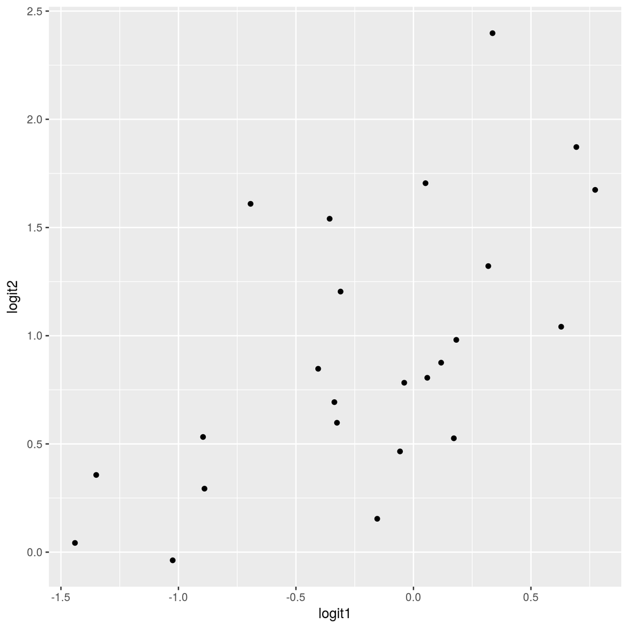

```r
ds <- data.frame(logit1 = logit(pim[,1]), logit2 = logit(pim[,1]+pim[,2])) # note: logit() from package faraway
ggp <- ggplot(data = ds, mapping = aes(x=logit1, y=logit2)) +
  geom_point()
print(ggp)
```

Alternatively, the difference of above logits should follow a line parallel to abscissa:

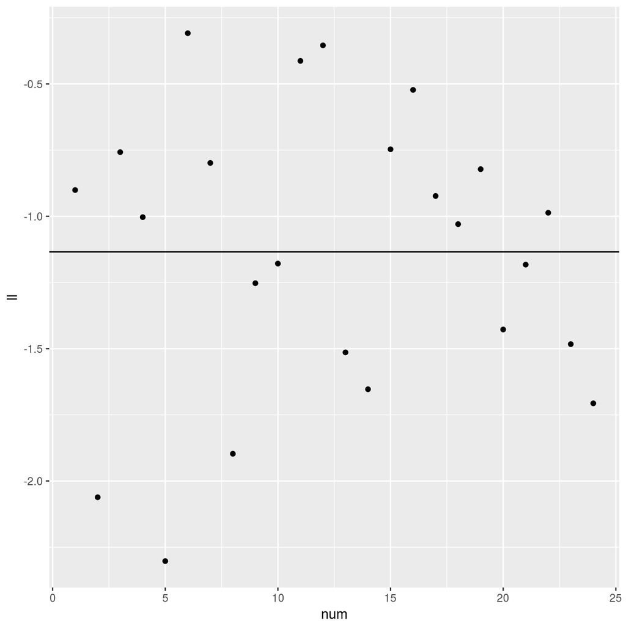

```r
ds$num <- 1:nrow(ds)
ds$ll <- ds$logit1-ds$logit2

ggp <- ggplot(data = ds, mapping = aes(x=num, y=ll)) +
  geom_point() +
  geom_hline(mapping = aes(yintercept = mean(ll)))
print(ggp)
```

It is questionable whether these can be considered sufficiently constant, but at least there is no trend.

To obatin the coefficients, we can use:

```r
pomod$coefficients
```

```
##    nincome
## 0.01311984
```

or

```r
coef(pomod)
```

```
##    nincome
## 0.01311984
```

And then, to calculate the odds-ratios for independent variables, we can use:

```r
exp(pomod$coefficients)
```

```
##  nincome
## 1.013206
```

We can say that the odds of moving from Democrat to Independent/Republican category (or from Democrat/Independent to Republican) increase by a factor of exp(0.013120) = 1.0132 as income increases by one unit ($1000).

There are also ($k$-1) intercepts, where $k$ is the number of levels of the response variable. The inverse of link function of interceps returns the “baseline” probability of levels of dependent variable when predictors are set to 0 or to their reference level (if the predictors are factors).

```r
pomod$zeta
```

```
##   Democrat|Independent Independent|Republican
##              0.2091045              1.2915566
```

```r
ilogit(pomod$zeta) # Note: ilogit==inverse logit
```

```
##   Democrat|Independent Independent|Republican
##              0.5520865              0.7844105
```

From the above result we may say that when `nincome` is 0, the estimated probability of being `Democrat` is 0.5521, the probability of being `Independent` is 0.7844-0.5521 = 0.2323, and the probability of being `Republican` is 1-0.7844 = 0.2156, as shown in following lines of code.

The estimated probability of being a Democrat, when income is 0, is:

```r
ilogit(pomod$zeta)[1]
```

```
## Democrat|Independent
##            0.5520865
```

The estimated probability of being an Indipendent, when income is 0, is:

```r
ilogit(pomod$zeta)[2] - ilogit(pomod$zeta)[1]
```

```
## Independent|Republican
##              0.2323241
```

The estimated probability of being a Republican when, income is 0, is:

```r
1 - ilogit(pomod$zeta)[2]
```

```
## Independent|Republican
##              0.2155895
```

The summary of final model is:

```r
summary(pomod)
```

```
##
## Re-fitting to get Hessian
```

```
## Call:
## polr(formula = sPID ~ nincome, data = nes96)
##
## Coefficients:
##           Value Std. Error t value
## nincome 0.01312   0.001971   6.657
##
## Intercepts:
##                        Value   Std. Error t value
## Democrat|Independent    0.2091  0.1123     1.8627
## Independent|Republican  1.2916  0.1201    10.7526
##
## Residual Deviance: 1995.363
## AIC: 2001.363
```

Deviances and number of parameters of multilogit and ordered logit for complete and reduced (final) models, and for Multinomial Logit model are:

```r
c(deviance(pomod0), pomod0$edf)
```

```
## [1] 1984.211   10.000
```

```r
c(deviance(mmod0), mmod0$edf)
```

```
## [1] 1968.333   18.000
```

```r
c(deviance(pomod), pomod$edf)
```

```
## [1] 1995.363    3.000
```

```r
c(deviance(mmod), mmod$edf)
```

```
## [1] 1985.424    4.000
```

To know the number of residual degrees of freedom:

```r
pomod$df.residual
```

```
## [1] 941
```

Whereas to produce predictions we can use, as usual, the `predict()` function:

```r
predict(pomod,data.frame(nincome=il,row.names=il), type="probs")
```

```
##      Democrat Independent Republican
## 8   0.5260129   0.2401191  0.2338679
## 26  0.4670450   0.2541588  0.2787962
## 42  0.4153410   0.2617693  0.3228897
## 58  0.3654362   0.2641882  0.3703756
## 74  0.3182635   0.2612285  0.4205080
## 90  0.2745456   0.2531189  0.4723355
## 107 0.2324161   0.2395468  0.5280371
```

```r
predict(pomod,data.frame(nincome=il,row.names=il))
```

```
## [1] Democrat   Democrat   Democrat   Republican Republican Republican
## [7] Republican
## Levels: Democrat Independent Republican
```

To obtain the probabilities, we can use the following:

```r
ilogit(pomod$zeta[1] - pomod$coefficients*il)
```

```
## [1] 0.5260129 0.4670450 0.4153410 0.3654362 0.3182635 0.2745456 0.2324161
```

```r
ilogit(pomod$zeta[2] - pomod$coefficients*il) - ilogit(pomod$zeta[1] - pomod$coefficients*il)
```

```
## [1] 0.2401191 0.2541588 0.2617693 0.2641882 0.2612285 0.2531189 0.2395468
```

```r
1 - ilogit(pomod$zeta[2] - pomod$coefficients*il)
```

```
## [1] 0.2338679 0.2787962 0.3228897 0.3703756 0.4205080 0.4723355 0.5280371
```

```r
summary(pomod)
```

```
##
## Re-fitting to get Hessian
```

```
## Call:
## polr(formula = sPID ~ nincome, data = nes96)
##
## Coefficients:
##           Value Std. Error t value
## nincome 0.01312   0.001971   6.657
##
## Intercepts:
##                        Value   Std. Error t value
## Democrat|Independent    0.2091  0.1123     1.8627
## Independent|Republican  1.2916  0.1201    10.7526
##
## Residual Deviance: 1995.363
## AIC: 2001.363
```

[figure not shown]

```r
x <- seq(-4,4,by=0.05)
par(mfrow=c(3,1))
plot(x,dlogis(x),type="l",main="Probabilites for income=$0")
minx=-4
maxx=.2091
x1=c(seq(minx,maxx,by=.01))
y1=dlogis(x1)
polygon(c(minx,x1,maxx), c(0,y1,0), density=20, col = "blue", angle=45)
minx=.2091
maxx=1.2916
x1=c(seq(minx,maxx,by=.01))
y1=dlogis(x1)
polygon(c(minx,x1,maxx), c(0,y1,0), density=20, col = "red",angle=-45)
minx=1.2916
maxx=4
x1=c(seq(minx,maxx,by=.01))
y1=dlogis(x1)
polygon(c(minx,x1,maxx), c(0,y1,0), density=20, col = "green",angle=45)
legend(x = "topleft",legend = c("Democrat","Independent","Republican"),
       fill = c("blue","red","green"),angle = c(45,-45,45),density = 40,
       border = c("blue","red","green"),bty = "n")
#abline(v=c(0.2091,1.2916),col="blue")

plot(x,dlogis(x),type="l",main="Probabilites for income=$100,000")
minx <- -4
maxx <- .2091-50*0.013120
x1 <- c(seq(minx,maxx,by=.01))
y1 <- dlogis(x1)
polygon(c(minx,x1,maxx), c(0,y1,0), density=20, col = "blue", angle=45)
minx <- .2091-50*0.013120
maxx <- 1.2916-50*0.013120
x1 <- c(seq(minx,maxx,by=.01))
y1 <- dlogis(x1)
polygon(c(minx,x1,maxx), c(0,y1,0), density=20, col = "red",angle=-45)
minx <- 1.2916-50*0.013120
maxx <- 4
x1 <- c(seq(minx,maxx,by=.01))
y1 <- dlogis(x1)
polygon(c(minx,x1,maxx), c(0,y1,0), density=20, col = "green",angle=45)
legend(x = "topleft",legend = c("Democrat","Independent","Republican"),
       fill = c("blue","red","green"),angle = c(45,-45,45),density = 40,
       border = c("blue","red","green"),bty = "n")
#abline(v=c(0.2091,1.2916)-50*0.013120,lty=2,col="red")

plot(x,dlogis(x),type="l",main="Probabilites for income=$200,000")
minx <- -4
maxx <- .2091-100*0.013120
x1 <- c(seq(minx,maxx,by=.01))
y1 <- dlogis(x1)
polygon(c(minx,x1,maxx), c(0,y1,0), density=20, col = "blue", angle=45)
minx <- .2091-100*0.013120
maxx <- 1.2916-100*0.013120
x1 <- c(seq(minx,maxx,by=.01))
y1 <- dlogis(x1)
polygon(c(minx,x1,maxx), c(0,y1,0), density=20, col = "red",angle=-45)
minx <- 1.2916-100*0.013120
maxx <- 4
x1 <- c(seq(minx,maxx,by=.01))
y1 <- dlogis(x1)
polygon(c(minx,x1,maxx), c(0,y1,0), density=20, col = "green",angle=45)
legend(x = "topleft",legend = c("Democrat","Independent","Republican"),fill = c("blue","red","green"),angle = c(45,-45,45),density = 40,border = c("blue","red","green"),bty = "n")
#abline(v=c(0.2091,1.2916)-100*0.013120,lty=5,col="green")
```

Probability of being a `Democrat` is given by the area lying to the left of the leftmost of each pair of lines, while the probability of being a `Republican` is given by the area to the right of the rightmost of the pair. `Independent` probabilities are represented by the area in between.

## Example: Housholders in Copenhagen

Let us work again with the above example data on householders in Copenhagen, and we let consider the `Sat` dependent variable as an ordered factor (as actually is).

### Data description

1681 householders from a study of satisfaction with housing conditions in Copenhagen who were surveyed on:

- the type (`Type`) of rental accommodation they occupied
- the degree of contact (`Cont`) they had with other residents
- their feeling of influence (`Infl`) on apartment management
- their level of satisfaction (`Sat`) with their housing conditions

We want to check if the satisfation level may be related to other (independent) variables.

### Data loading

```r
data(housing)
head(housing)
```

```
## # A tibble: 6 x 5
##      Sat   Infl   Type   Cont  Freq
##    <ord> <fctr> <fctr> <fctr> <int>
## 1    Low    Low  Tower    Low    21
## 2 Medium    Low  Tower    Low    21
## 3   High    Low  Tower    Low    28
## 4    Low Medium  Tower    Low    34
## 5 Medium Medium  Tower    Low    22
## 6   High Medium  Tower    Low    36
```

```r
str(housing)
```

```
## Classes 'tbl_df', 'tbl' and 'data.frame':    72 obs. of  5 variables:
##  $ Sat : Ord.factor w/ 3 levels "Low"<"Medium"<..: 1 2 3 1 2 3 1 2 3 1 ...
##  $ Infl: Factor w/ 3 levels "Low","Medium",..: 1 1 1 2 2 2 3 3 3 1 ...
##  $ Type: Factor w/ 4 levels "Tower","Apartment",..: 1 1 1 1 1 1 1 1 1 2 ...
##  $ Cont: Factor w/ 2 levels "Low","High": 1 1 1 1 1 1 1 1 1 1 ...
##  $ Freq: int  21 21 28 34 22 36 10 11 36 61 ...
```

```r
summary(housing)
```

```
##      Sat         Infl           Type      Cont         Freq
##  Low   :24   Low   :24   Tower    :18   Low :36   Min.   : 3.00
##  Medium:24   Medium:24   Apartment:18   High:36   1st Qu.:10.00
##  High  :24   High  :24   Atrium   :18             Median :19.50
##                          Terrace  :18             Mean   :23.35
##                                                   3rd Qu.:31.75
##                                                   Max.   :86.00
```

### Inference and models

Let us fit a first full model with `polr()`:

```r
(ord_hous0 <- polr(Sat ~ Infl*Type*Cont, weights=Freq, data=housing))
```

```
## Call:
## polr(formula = Sat ~ Infl * Type * Cont, data = housing, weights = Freq)
##
## Coefficients:
##                        InflMedium                          InflHigh
##                       -0.16823008                        0.88317160
##                     TypeApartment                        TypeAtrium
##                       -1.23649484                       -0.42501098
##                       TypeTerrace                          ContHigh
##                       -1.06680499                        0.51791251
##          InflMedium:TypeApartment            InflHigh:TypeApartment
##                        1.13138932                        0.82210245
##             InflMedium:TypeAtrium               InflHigh:TypeAtrium
##                        0.68995164                       -0.38301890
##            InflMedium:TypeTerrace              InflHigh:TypeTerrace
##                        0.91237635                        0.37046830
##               InflMedium:ContHigh                 InflHigh:ContHigh
##                        0.06710079                        0.03718539
##            TypeApartment:ContHigh               TypeAtrium:ContHigh
##                        0.03485522                       -0.31085614
##              TypeTerrace:ContHigh InflMedium:TypeApartment:ContHigh
##                       -0.76088003                       -0.08335132
##   InflHigh:TypeApartment:ContHigh    InflMedium:TypeAtrium:ContHigh
##                       -0.21235461                       -0.07957413
##      InflHigh:TypeAtrium:ContHigh   InflMedium:TypeTerrace:ContHigh
##                        0.29526797                       -0.31377673
##     InflHigh:TypeTerrace:ContHigh
##                        0.56073917
##
## Intercepts:
##  Low|Medium Medium|High
##  -0.8212469   0.3855417
##
## Residual Deviance: 3446.458
## AIC: 3496.458
```

```r
summary(ord_hous0)
```

```
##
## Re-fitting to get Hessian
```

```
## Call:
## polr(formula = Sat ~ Infl * Type * Cont, data = housing, weights = Freq)
##
## Coefficients:
##                                      Value Std. Error  t value
## InflMedium                        -0.16823     0.2944 -0.57146
## InflHigh                           0.88317     0.3478  2.53944
## TypeApartment                     -1.23649     0.2960 -4.17709
## TypeAtrium                        -0.42501     0.3942 -1.07809
## TypeTerrace                       -1.06680     0.4183 -2.55022
## ContHigh                           0.51791     0.3162  1.63810
## InflMedium:TypeApartment           1.13139     0.3931  2.87786
## InflHigh:TypeApartment             0.82210     0.4465  1.84126
## InflMedium:TypeAtrium              0.68995     0.5625  1.22654
## InflHigh:TypeAtrium               -0.38302     0.6163 -0.62144
## InflMedium:TypeTerrace             0.91238     0.5426  1.68154
## InflHigh:TypeTerrace               0.37047     0.6370  0.58159
## InflMedium:ContHigh                0.06710     0.4270  0.15715
## InflHigh:ContHigh                  0.03719     0.5810  0.06400
## TypeApartment:ContHigh             0.03486     0.3998  0.08718
## TypeAtrium:ContHigh               -0.31086     0.5078 -0.61213
## TypeTerrace:ContHigh              -0.76088     0.5185 -1.46734
## InflMedium:TypeApartment:ContHigh -0.08335     0.5392 -0.15457
## InflHigh:TypeApartment:ContHigh   -0.21235     0.6895 -0.30799
## InflMedium:TypeAtrium:ContHigh    -0.07957     0.7212 -0.11033
## InflHigh:TypeAtrium:ContHigh       0.29527     0.8630  0.34214
## InflMedium:TypeTerrace:ContHigh   -0.31378     0.6963 -0.45065
## InflHigh:TypeTerrace:ContHigh      0.56074     0.9049  0.61970
##
## Intercepts:
##             Value   Std. Error t value
## Low|Medium  -0.8212  0.2217    -3.7046
## Medium|High  0.3855  0.2208     1.7458
##
## Residual Deviance: 3446.458
## AIC: 3496.458
```

Let us reduce the model

```r
dropterm(ord_hous0, test="Chisq")
```

```
## Single term deletions
##
## Model:
## Sat ~ Infl * Type * Cont
##                Df    AIC   LRT Pr(Chi)
## <none>            3496.5
## Infl:Type:Cont  6 3486.6 2.125  0.9079
```

```r
ord_hous1 <- update(ord_hous0, . ~ . -Infl:Type:Cont)
dropterm(ord_hous1, test="Chisq")
```

```
## Single term deletions
##
## Model:
## Sat ~ Infl + Type + Cont + Infl:Type + Infl:Cont + Type:Cont
##           Df    AIC     LRT  Pr(Chi)
## <none>       3486.6
## Infl:Type  6 3496.3 21.7174 0.001362 **
## Infl:Cont  2 3482.7  0.1116 0.945740
## Type:Cont  3 3488.5  7.9245 0.047597 *
## ---
## Signif. codes:  0 '***' 0.001 '**' 0.01 '*' 0.05 '.' 0.1 ' ' 1
```

```r
ord_hous <- update(ord_hous1, . ~ . -Infl:Cont)
dropterm(ord_hous, test="Chisq")
```

```
## Single term deletions
##
## Model:
## Sat ~ Infl + Type + Cont + Infl:Type + Type:Cont
##           Df    AIC    LRT  Pr(Chi)
## <none>       3482.7
## Infl:Type  6 3492.5 21.788 0.001323 **
## Type:Cont  3 3484.6  7.945 0.047162 *
## ---
## Signif. codes:  0 '***' 0.001 '**' 0.01 '*' 0.05 '.' 0.1 ' ' 1
```

We retain the main effects, `Infl:Type` and `Type:Cont`. In multilogit model, the first interaction was “less significant” than here, whereas the second interaction was not significant at all.

```r
summary(ord_hous)
```

```
##
## Re-fitting to get Hessian
```

```
## Call:
## polr(formula = Sat ~ Infl + Type + Cont + Infl:Type + Type:Cont,
##     data = housing, weights = Freq)
##
## Coefficients:
##                            Value Std. Error t value
## InflMedium               -0.1363     0.2132 -0.6390
## InflHigh                  0.9009     0.2769  3.2533
## TypeApartment            -1.1847     0.2368 -5.0026
## TypeAtrium               -0.4608     0.3120 -1.4767
## TypeTerrace              -1.0516     0.3156 -3.3320
## ContHigh                  0.5546     0.1949  2.8451
## InflMedium:TypeApartment  1.0864     0.2667  4.0732
## InflHigh:TypeApartment    0.7082     0.3322  2.1323
## InflMedium:TypeAtrium     0.6490     0.3453  1.8797
## InflHigh:TypeAtrium      -0.1920     0.4125 -0.4654
## InflMedium:TypeTerrace    0.7304     0.3319  2.2010
## InflHigh:TypeTerrace      0.6640     0.4352  1.5257
## TypeApartment:ContHigh   -0.0535     0.2405 -0.2224
## TypeAtrium:ContHigh      -0.2682     0.3176 -0.8443
## TypeTerrace:ContHigh     -0.7935     0.3136 -2.5305
##
## Intercepts:
##             Value   Std. Error t value
## Low|Medium  -0.8026  0.1862    -4.3111
## Medium|High  0.4028  0.1852     2.1752
##
## Residual Deviance: 3448.695
## AIC: 3482.695
```

We use `anova()` to see if the reduced model lost important information with respect to the full model:

```r
anova(ord_hous0, ord_hous)
```

```
## Likelihood ratio tests of ordinal regression models
##
## Response: Sat
##                                        Model Resid. df Resid. Dev   Test
## 1 Infl + Type + Cont + Infl:Type + Type:Cont      1664   3448.695
## 2                         Infl * Type * Cont      1656   3446.458 1 vs 2
##      Df LR stat.   Pr(Chi)
## 1
## 2     8 2.236581 0.9728862
```

The reduced model is ok.

As in previous example, now we check the proportionality of odds:

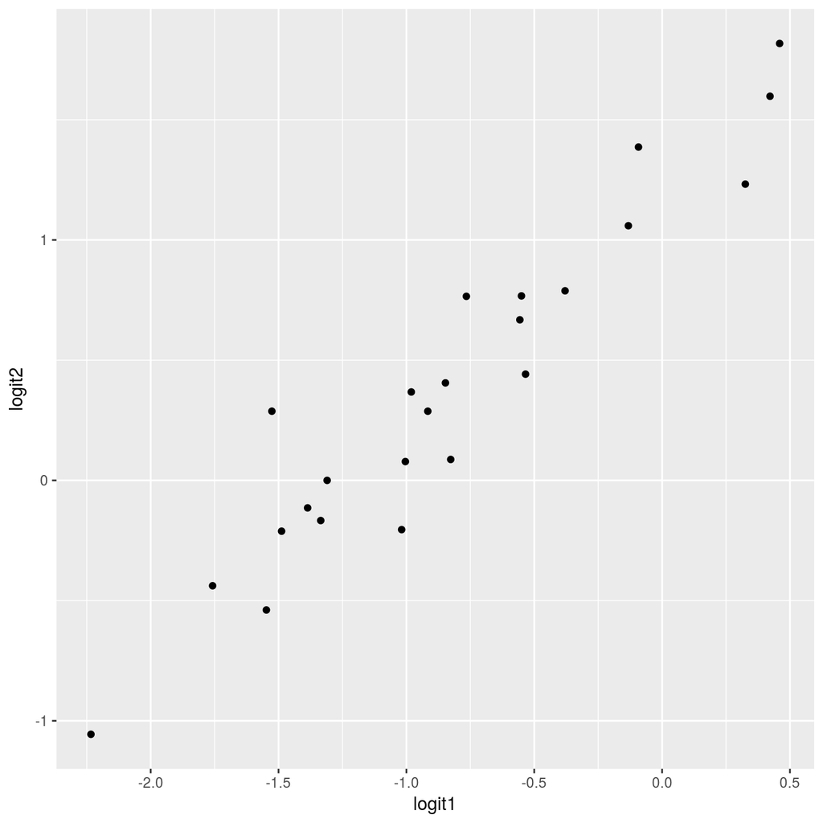

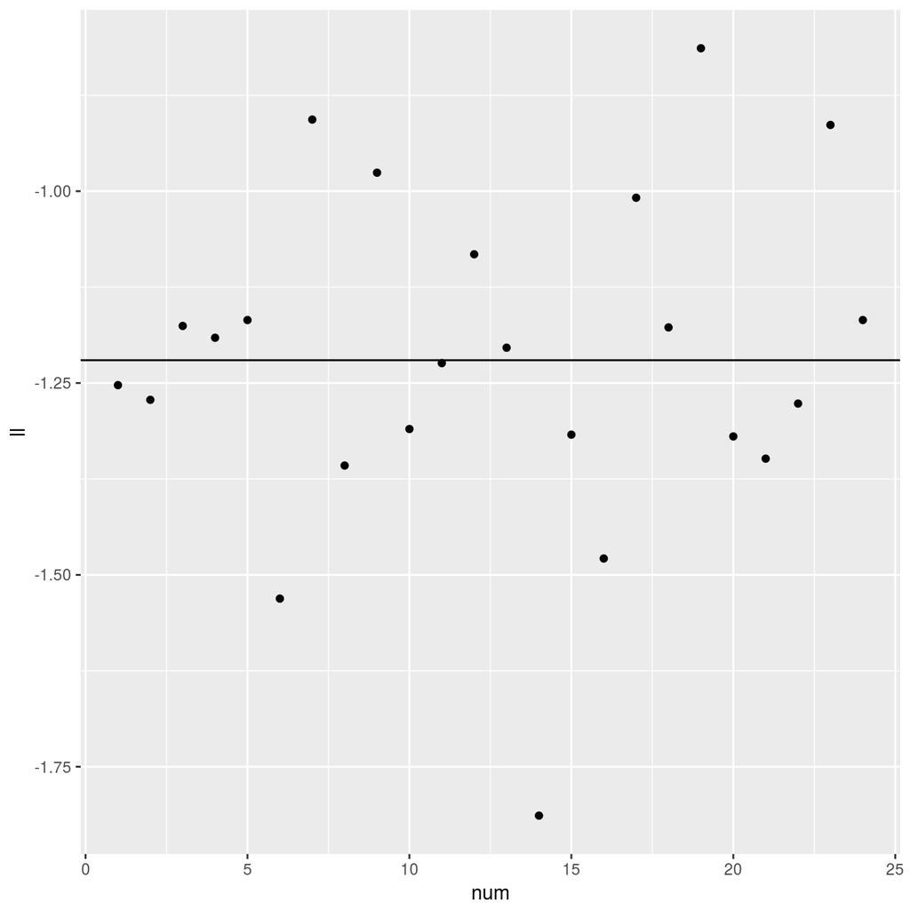

```r
tbl <- ftable(xtabs(Freq ~ Infl+Type+Cont+Sat, data=housing))

logit1 <- log(tbl[,1]/(tbl[,2]+tbl[,3]))
logit2 <- log((tbl[,1]+tbl[,2])/tbl[,3])

ds <- data.frame(logit1 = logit1, logit2 = logit2, ll = logit1-logit2, num = 1:length(logit1))

ggp <- ggplot(data = ds, mapping = aes(x=logit1, y=logit2)) +
  geom_point()
print(ggp)

ggp <- ggplot(data = ds, mapping = aes(x=num, y=ll)) +
  geom_point() +
  geom_hline(mapping = aes(yintercept=mean(ll)))
print(ggp)
```

In this case the ordered logit model seems clearly more adequate than non ordered one.